# Duração e presença feminina entre os 1º lugares da Billboard Hot 100 (1960–2026)

ME430 - Técnicas de Amostragem

Dominique Ribeiro Cardoso Veloso - RA: 206786

Fernanda Sauer Kruger Di Vincenzo - RA: 280867

Isabela Diniz Cia - RA: 280902

Matheus Rodrigues da Silva - RA: 259256

2026-11-24

# 1 Planejamento Metodológico

## 1.1 Definição do Problema

O objetivo deste trabalho é estimar, para cada década, a duração média e a proporção de artistas mulheres entre as músicas que ocuparam o 1º lugar da parada semanal Billboard Hot 100 (Billboard 2026), de modo a comparar como essas características se modificaram ao longo do tempo.

A população-alvo é formada por todas as semanas de divulgação da Billboard Hot 100 entre 04/01/1960 e 17/10/2026, num total de N = 3.486 semanas. Cada semana constitui uma unidade elementar (UE), representada pela música que ocupou o 1º lugar naquela semana. Como o interesse está na música mais popular de cada semana, e não na música em si, uma canção que permaneceu no topo por várias semanas é contada em cada uma delas, o que reflete o fato de ter sido a preferida do público por mais tempo. O quadro amostral é a lista completa das semanas da parada (arquivo `top_hits_number_one.csv`), em que cada semana aparece uma única vez; assim, a população amostrada coincide com a população-alvo.

A população é dividida em H = 7 períodos: as décadas de 1960 a 2010 e o período 2020–2026, cada um com $N_h$ semanas. O período 2020–2026 é **parcial**: vai até 17/10/2026 e tem 355 semanas, contra cerca de 522 nas décadas completas. Por isso, ele é identificado com um asterisco (2020–2026*) nos resultados, e suas estimativas descrevem esses anos, e não uma década inteira.

No planejamento e na primeira etapa da coleta, a população incluía também as semanas de 1958–1959 (74 semanas, do início da parada, em 04/08/1958, até o fim de 1959), num total de 3.560 semanas e 8 estratos. Na análise final, esse período foi retirado do escopo (Seção 2.2): ele não é uma década, cobre menos de um ano e meio e não seria comparável aos demais. Como os estratos são sorteados de forma independente, retirá-lo não altera nenhuma estimativa dos outros períodos.

Para cada semana sorteada são registradas a duração da música, em segundos, e o gênero do artista principal. Os parâmetros de interesse em cada período $h$ são:

- a **duração média** $\bar{Y}_h$ das músicas das $N_h$ semanas;
- a **proporção** $P_h$ de semanas em que o artista principal do 1º lugar era uma mulher ou um grupo formado só por mulheres.

A segunda variável mede **liderança feminina**: se uma mulher era o primeiro nome creditado. Ela não mede a participação de mulheres em qualquer posição. Grupos mistos e participações especiais (*featuring*) de mulheres em músicas lideradas por homens não contam como artista mulher (ver os critérios na Seção 1.4). Como análise complementar, estima-se também a proporção de semanas em que o artista principal era uma mulher ou um grupo com pelo menos uma mulher (feminino ou misto). Essa medida ainda não inclui as participações especiais.

O quadro amostral, porém, não traz nenhuma das duas variáveis: tem apenas a data, o título e o artista de cada semana (e 10 semanas vieram sem título e artista, corrigidos pela data). Por isso, antes do sorteio, a duração e o gênero foram buscados automaticamente na base MusicBrainz (MetaBrainz Foundation 2026) para todas as semanas da parada. A busca retornou a duração de 85% das semanas e o gênero de 77%. Esses dados automáticos não passaram por revisão e não substituem a coleta da amostra: eles foram usados apenas como uma **população de referência** aproximada, para planejar o tamanho da amostra e comparar planos amostrais por simulação. Faltava decidir quantas semanas coletar.

## 1.2 Tamanho da Amostra

Para dimensionar a amostra, sorteou-se uma amostra piloto de 30 semanas por período na população de referência e, com o desvio-padrão $s$ da duração observado em cada período, calculou-se o tamanho necessário para margens de erro de $E = 10$ segundos na duração e $e = 10$ pontos percentuais na proporção, com 95% de confiança. Para a proporção usou-se o pior caso, $\hat{p} = 0{,}5$, e em ambos os casos aplicou-se a correção para população finita:

$$n_0 = \left(\frac{z\,s}{E}\right)^2, \qquad
n_0^{(p)} = \frac{z^2\,\hat{p}\,(1-\hat{p})}{e^2}, \qquad
n = \frac{n_0}{1 + \dfrac{n_0 - 1}{N_h}}.$$

Em cada período, o tamanho necessário é o maior entre o da duração e o da proporção (Tabela 1.1).

Tabela 1.1: Tamanho de amostra necessário em cada período, calculado com a amostra piloto da população de referência.

| Período | $N_h$ (com dados da API) | $s$ (s) | $n$ duração | $n$ proporção | $n$ necessário |
| --- | --- | --- | --- | --- | --- |
| 1958–1959 | 45 | 22,8 | 15 | 31 | 31 |
| 1960–1969 | 341 | 93,4 | 170 | 76 | 170 |
| 1970–1979 | 333 | 44,8 | 63 | 75 | 75 |
| 1980–1989 | 345 | 52,3 | 81 | 76 | 81 |
| 1990–1999 | 392 | 38,1 | 49 | 78 | 78 |
| 2000–2009 | 375 | 27,9 | 28 | 77 | 77 |
| 2010–2019 | 364 | 25,9 | 25 | 77 | 77 |
| 2020–2026 | 212 | 41,9 | 52 | 67 | 67 |
| Total | 2407 |  |  |  | 656 |

O total necessário seria de 656 semanas. Como a duração e o gênero precisam ser conferidos individualmente para cada música sorteada, esse tamanho era incompatível com o tempo disponível do grupo. Fixou-se então um orçamento de 240 semanas, e a pergunta passou a ser como dividi-las entre os períodos.

## 1.3 Delineamento Amostral

O plano adotado é uma **amostragem aleatória estratificada** em um único estágio, sem uso de conglomerados (Bolfarine and Bussab 2005; Cochran 1977). Os períodos funcionam como estratos e, em cada um deles, seleciona-se de forma independente uma **amostra aleatória simples sem reposição** (AAS) diretamente do quadro amostral. A estratificação garante que todos os períodos estejam representados e permite estimar cada um separadamente, o que é essencial, já que o objetivo é compará-los.

### 1.3.1 Escolha da alocação

Para repartir as 240 semanas entre os 8 estratos do planejamento, foram consideradas três alocações:

$$\text{proporcional: } n_h = n\,\frac{N_h}{N}, \qquad
\text{Neyman: } n_h = n\,\frac{N_h\,S_h}{\sum_{k} N_k\,S_k}, \qquad
\text{igual: } n_h = \frac{n}{H} = 30.$$

A alocação de Neyman é a ótima para estimar a média de toda a população, porque dá mais semanas aos períodos maiores e mais variáveis. Para calculá-la, usaram-se os desvios-padrão $S_h$ observados nas 240 semanas da etapa 1. A Tabela 1.2 mostra quantas semanas cada alocação daria a cada período: a proporcional deixaria 1958–1959 com 5 semanas, e a de Neyman, com 3.

Tabela 1.2: Número de semanas por período em cada alocação, para n = 240.

| Período | Proporcional | Neyman | Igual |
| --- | --- | --- | --- |
| 1958–1959 | 5 | 3 | 30 |
| 1960–1969 | 35 | 27 | 30 |
| 1970–1979 | 35 | 43 | 30 |
| 1980–1989 | 35 | 55 | 30 |
| 1990–1999 | 35 | 27 | 30 |
| 2000–2009 | 35 | 27 | 30 |
| 2010–2019 | 35 | 37 | 30 |
| 2020–2026 | 24 | 22 | 30 |

Para escolher entre elas, as três alocações e uma AAS simples de mesmo tamanho foram comparadas por simulação de Monte Carlo: sortearam-se 1.000 amostras de cada plano na população de referência e, em cada uma, calcularam-se as estimativas por período e a estimativa de toda a população, $\bar{y}_{st} = \sum_h W_h\,\bar{y}_h$, com $W_h = N_h/N$. Para a média de toda a população, os planos praticamente empatam: o erro-padrão empírico da duração ficou entre 2,8 e 3,3 segundos, e os intervalos de 95% cobriram o valor de referência em 94% a 95% das amostras. O mesmo vale para a proporção de mulheres (Tabela 1.3).

Tabela 1.3: Desempenho de cada plano na estimativa de toda a população, em 1.000 amostras de tamanho 240 sorteadas na população de referência: erro-padrão empírico (desvio-padrão das estimativas) e porcentagem de intervalos de 95% que contêm o valor de referência.

| Plano | EP empírico da duração (s) | Cobertura do IC 95% (duração) | EP empírico da proporção (p.p.) | Cobertura do IC 95% (proporção) |
| --- | --- | --- | --- | --- |
| AAS | 3,3 | 94,4% | 2,75 | 94,9% |
| Proporcional | 2,8 | 95,0% | 2,73 | 94,7% |
| Neyman | 3,0 | 94,0% | 2,77 | 94,6% |
| Igual | 3,1 | 94,5% | 2,70 | 96,1% |

A diferença aparece nas estimativas por período, que são o objetivo deste trabalho. A Figura 1.1 mostra, para cada alocação, a média das estimativas e dos limites dos intervalos de 95% nas 1.000 amostras. Nas décadas completas, os três planos têm intervalos parecidos. Em 1958–1959, porém, a alocação de Neyman sorteia só 2 semanas na população de referência, e o seu intervalo médio vai de 0 min 12 s a 5 min 17 s, contra 2 min 39 s a 2 min 49 s na alocação igual.

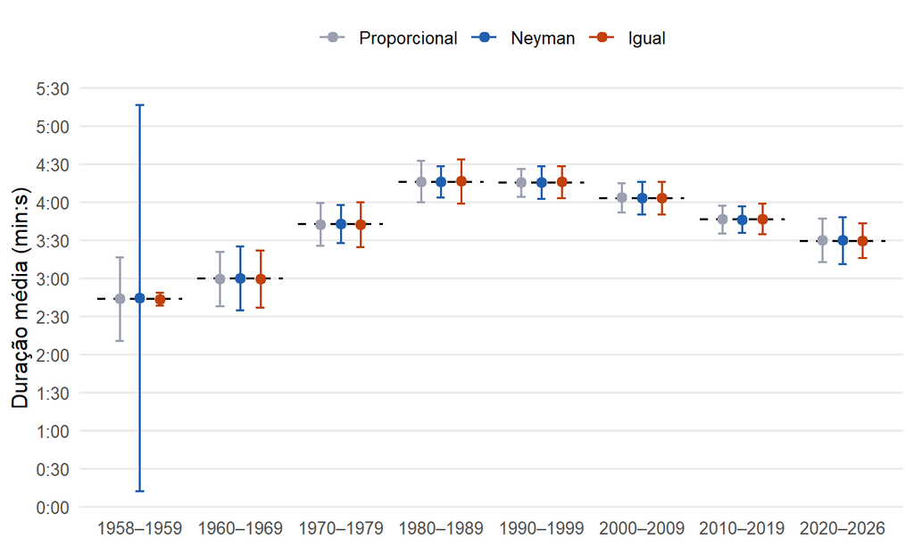

Figura 1.1: Média das estimativas e dos limites dos intervalos de 95% da duração média em cada período, nas 1.000 amostras de cada alocação sorteadas na população de referência. A linha tracejada é o valor de referência.

A Tabela 1.4 resume a precisão prevista de cada alocação, aplicando as fórmulas da AAS ao $n_h$ que cada uma daria a cada período, com os desvios-padrão da etapa 1. No erro-padrão da média de toda a população, os três planos ficam entre 2,6 e 2,9 segundos. No pior período, porém, a margem de erro da duração é de 23 s com a alocação igual, contra 27 s com a proporcional e 54 s com a de Neyman; na proporção, no pior caso $P_h = 0{,}5$, é de 18 pontos percentuais, contra 47 e 68.

Tabela 1.4: Precisão prevista de cada alocação com n = 240: erro-padrão da estimativa de toda a população e maior margem de erro (95%) entre os 8 períodos. Na proporção, usa-se o pior caso P = 0,5.

| Alocação | EP da média geral (s) | Maior margem da duração (s) | Maior margem da proporção (p.p.) |
| --- | --- | --- | --- |
| Proporcional | 2,7 | 27 | 47 |
| Neyman | 2,6 | 54 | 68 |
| Igual | 2,9 | 23 | 18 |

Como cada período é analisado isoladamente, optou-se pela **alocação igual**, que leva a precisões parecidas em todos os períodos, facilita a comparação entre eles e evita deixar os períodos menores com poucas semanas. Com isso, o plano ficou definido.

### 1.3.2 Sorteio em duas etapas

O sorteio foi feito em duas etapas, ambas no R, com semente fixa e com a alocação igual:

1. **Etapa 1** (semente 2026): AAS sem reposição de 30 semanas em cada um dos 8 estratos, num total de 240 semanas (Seção 2.1).
2. **Etapa 2** (semente 2027): AAS sem reposição de mais 30 semanas por período, entre as semanas que **não** tinham saído na etapa 1 (Seção 2.2).

A união das duas etapas é uma AAS sem reposição de 60 semanas em cada período: todo subconjunto de 60 semanas do estrato tem a mesma probabilidade de ser o selecionado. Por isso, os estimadores e as fórmulas de variância são os da AAS, com $n_h = 30$ na etapa 1 e $n_h = 60$ no resultado final, sem nenhum ajuste pela etapa em que a semana foi sorteada. A alocação continua igual, de modo que a comparação da seção anterior continua justificando o plano.

Dentro de cada período, todas as semanas têm a mesma **probabilidade de inclusão**, $\pi_{hi} = n_h/N_h$, que coincide com a **fração amostral** $f_h = n_h/N_h$. Na análise final, ela é de 0,115 nas décadas completas e de 0,169 em 2020–2026 (Tabela 1.5). Essa diferença não afeta as estimativas por período, pois cada uma usa apenas a amostra do próprio estrato. Ela só precisaria ser corrigida, ponderando cada estrato por $W_h = N_h/N$, se o interesse fosse uma estimativa única para vários períodos juntos, como na comparação entre blocos de períodos da Seção 2.4.

Tabela 1.5: Análise final: número de semanas na população ($N_h$), tamanho da amostra ($n_h$), fração amostral ($f_h$) e probabilidade de inclusão de cada semana ($\pi_{hi}$) em cada período. *2020–2026 é um período parcial, até 17/10/2026.

| Período | $N_h$ | $n_h$ | $f_h = n_h/N_h$ | $\pi_{hi} = n_h/N_h$ |
| --- | --- | --- | --- | --- |
| 1960–1969 | 521 | 60 | 0,115 | 0,115 |
| 1970–1979 | 522 | 60 | 0,115 | 0,115 |
| 1980–1989 | 522 | 60 | 0,115 | 0,115 |
| 1990–1999 | 521 | 60 | 0,115 | 0,115 |
| 2000–2009 | 522 | 60 | 0,115 | 0,115 |
| 2010–2019 | 523 | 60 | 0,115 | 0,115 |
| 2020–2026* | 355 | 60 | 0,169 | 0,169 |
| Total | 3486 | 420 |  |  |

## 1.4 Protocolo de Coleta e Métodos de Estimação

### 1.4.1 Coleta da duração

A duração de interesse é a da **versão single** da música, isto é, a versão lançada comercialmente como single nos EUA. Uma mesma música costuma ter várias gravações (versão de álbum, single, *radio edit*, remasterizações, versões estendidas, ao vivo), e a escolha da versão muda bastante a duração. O protocolo final, descrito abaixo, foi aplicado a todas as semanas das duas etapas. Na etapa 1 a duração tinha sido obtida de forma mais simples, o que motivou essa revisão (Seção 2.1). A coleta foi feita no R, com consultas automatizadas a duas bases públicas, em três passos:

1. **MusicBrainz** (MetaBrainz Foundation 2026): busca-se o lançamento do tipo *single* com o título e o artista principal, lançado até o ano em que a música chegou ao 1º lugar. Dá-se preferência a lançamentos dos EUA e, entre eles, ao mais antigo. São descartados os formatos de 12 polegadas e as faixas marcadas como remix, versão estendida, ao vivo ou instrumental.
2. **Wikipedia** (Wikipedia 2026): lê-se a duração no quadro de informações da página da música, usando a versão marcada como single quando há mais de uma.
3. **Comparação e revisão:** quando as duas fontes concordam em até 5 segundos, a duração é aceita automaticamente. Quando só uma das fontes identifica a versão single e a outra não traz duração, usa-se essa fonte. Nos demais casos (fontes discordantes, nenhuma versão single identificada ou valores fora de 90 a 600 segundos, típicos de trechos e vinhetas), a música vai para **revisão manual**. A origem de cada duração está registrada na coluna `origem_duracao` da planilha `semanas_sorteadas.csv`.

Na revisão manual, prevaleceu a versão que a Wikipedia identifica como single. Quando a página distingue apenas a versão de álbum e a de rádio (*radio edit*), sem indicar qual foi o single, adotou-se a versão de álbum, mesmo critério das músicas confirmadas automaticamente. Esse critério é avaliado numa análise de sensibilidade (Seção 2.4.3).

### 1.4.2 Classificação do artista principal

O gênero foi obtido no cadastro do artista na MusicBrainz e conferido manualmente, com três critérios:

1. **Artista principal** é o primeiro nome creditado. Em duetos e participações, só ele é considerado.
2. **Grupos** são classificados como femininos apenas quando formados exclusivamente por mulheres. Grupos com homens e mulheres formam a categoria “misto”. A formação considerada é a da época do sucesso.
3. Uma semana conta como **“artista mulher”** ($y_{hi} = 1$) somente quando o artista principal é uma mulher ou um grupo só de mulheres. Grupos mistos e músicas lideradas por homens com participação de mulheres contam como $y_{hi} = 0$.

### 1.4.3 Estimação da duração média

Sendo $y_{hi}$ a duração, em segundos, da música da $i$-ésima semana sorteada no período $h$, a média do período é estimada pela média amostral, e a variância desse estimador, pela expressão da AAS sem reposição (Bolfarine and Bussab 2005):

$$\hat{\bar{Y}}_h = \bar{y}_h = \frac{1}{n_h}\sum_{i=1}^{n_h} y_{hi}, \qquad
s_h^2 = \frac{1}{n_h - 1}\sum_{i=1}^{n_h}\left(y_{hi} - \bar{y}_h\right)^2, \qquad
\widehat{\mathrm{Var}}(\bar{y}_h) = (1 - f_h)\,\frac{s_h^2}{n_h}.$$

A média amostral é não viesada para $\bar{Y}_h$, e $s_h^2$ é não viesado para a variância populacional $S_h^2$, de modo que a variância estimada também é não viesada. O fator $(1 - f_h)$ é a **correção para população finita**: como as semanas são sorteadas sem reposição, cada semana sorteada reduz a incerteza sobre as que restam. Na análise final, com $f_h \approx 0,11$ nas décadas completas, a correção reduz o erro-padrão em cerca de 6%; em 2020–2026, em cerca de 9%. O erro-padrão é $EP(\bar{y}_h) = \sqrt{\widehat{\mathrm{Var}}(\bar{y}_h)}$, e o intervalo de 95% de confiança é

$$\bar{y}_h \pm t_{n_h-1;\,0{,}025}\; EP(\bar{y}_h),$$

com a distribuição t de Student com $n_h - 1$ graus de liberdade, já que a variância é estimada a partir da própria amostra.

### 1.4.4 Estimação da proporção

Com $y_{hi} \in \{0, 1\}$, a proporção do período é estimada pela proporção amostral. Aplicando a fórmula anterior a uma variável indicadora, obtém-se a variância estimada (Bolfarine and Bussab 2005):

$$\hat{P}_h = \frac{1}{n_h}\sum_{i=1}^{n_h} y_{hi}, \qquad
\widehat{\mathrm{Var}}(\hat{P}_h) = (1 - f_h)\,\frac{\hat{P}_h\,(1 - \hat{P}_h)}{n_h - 1}.$$

O denominador $n_h - 1$ vem de $s_h^2 = \frac{n_h}{n_h - 1}\hat{P}_h(1 - \hat{P}_h)$ e torna o estimador da variância não viesado. O intervalo de 95% de confiança usa a aproximação normal:

$$\hat{P}_h \pm z_{0{,}025}\sqrt{\widehat{\mathrm{Var}}(\hat{P}_h)}, \qquad z_{0{,}025} = 1{,}96.$$

A aproximação é razoável quando há um número suficiente de semanas com e sem a característica na amostra. Na análise final, cada período tem $n_h = 60$ semanas, e o menor número observado de semanas com artista mulher foi 9.

### 1.4.5 Comparação entre períodos

As amostras dos estratos são independentes. Por isso, a variância da diferença entre as estimativas de dois períodos é a soma das variâncias:

$$\widehat{\mathrm{Var}}(\bar{y}_{h'} - \bar{y}_h) = \widehat{\mathrm{Var}}(\bar{y}_{h'}) + \widehat{\mathrm{Var}}(\bar{y}_h),$$

e analogamente para as proporções. Para as médias, usa-se a distribuição t com os graus de liberdade de Welch–Satterthwaite; para as proporções, a aproximação normal. Comparam-se os 6 pares de períodos consecutivos. Como são 6 comparações simultâneas, os intervalos das diferenças usam a correção de Bonferroni (nível $1 - 0{,}05/6$ em cada uma, para garantir 95% no conjunto) e os p-valores são ajustados pelo método de Holm. Uma diferença é considerada estatisticamente sustentada quando o seu intervalo não contém zero. A sobreposição dos intervalos individuais de cada período **não** é usada como teste.

Para comparar blocos de períodos (1960–1989 e 1990–2026), cada bloco é estimado pelo estimador estratificado (Bolfarine and Bussab 2005; Cochran 1977), que pondera os períodos por $W_h = N_h / \sum_{h \in \text{bloco}} N_h$:

$$\hat{P}_{\text{bloco}} = \sum_{h \in \text{bloco}} W_h \hat{P}_h, \qquad
\widehat{\mathrm{Var}}(\hat{P}_{\text{bloco}}) = \sum_{h \in \text{bloco}} W_h^2\, \widehat{\mathrm{Var}}(\hat{P}_h).$$

# 2 Execução e Resultados

## 2.1 Etapa 1: 30 semanas por período

Na etapa 1, sortearam-se no R, com a semente 2026, 30 semanas em cada um dos 8 estratos, por AAS sem reposição e de forma independente entre os estratos, num total de 240 semanas. Como algumas músicas permaneceram várias semanas no 1º lugar, essas semanas correspondem a 198 músicas distintas, e cada música foi consultada uma única vez.

Nessa primeira coleta, a duração foi registrada como a mediana das durações de todas as gravações que a MusicBrainz associava ao título e ao artista; nos casos em que a base não trazia a informação, usou-se a versão single informada na Wikipedia. O gênero foi classificado com os critérios da Seção 1.4, com conferência manual dos grupos e dos casos que a base classificou de forma incorreta (cantoras como Pink e Miley Cyrus, por exemplo, apareceram como grupo). Todas as 240 semanas tiveram duração e gênero registrados: 70 com artista mulher, 156 com artista homem e 14 com grupo misto.

A Tabela 2.1 mostra as estimativas obtidas. **Estes foram os resultados mostrados na apresentação do trabalho.** A duração média crescia de 2 min 43 s em 1958–1959 e 2 min 47 s em 1960–1969 até cerca de 4 min 26 s nos anos 1980 e 1990, e depois caía até 3 min 22 s em 2020–2026. A proporção de semanas com artista mulher, nula na amostra de 1958–1959, ficava entre 20% e 23% de 1960 a 1989 e entre 33% e 47% a partir dos anos 1990.

Tabela 2.1: Etapa 1: estimativas com 30 semanas por período e a coleta original da duração (resultados mostrados na apresentação).

| Período | Duração média (min:s) | IC 95% | Artista mulher | IC 95% |
| --- | --- | --- | --- | --- |
| 1958–1959 | 2:43 | 2:36 a 2:49 | 0% | 0% a 0% |
| 1960–1969 | 2:47 | 2:36 a 2:59 | 20% | 6% a 34% |
| 1970–1979 | 3:47 | 3:29 a 4:05 | 20% | 6% a 34% |
| 1980–1989 | 4:26 | 4:02 a 4:49 | 23% | 8% a 38% |
| 1990–1999 | 4:25 | 4:14 a 4:37 | 47% | 29% a 64% |
| 2000–2009 | 3:57 | 3:45 a 4:08 | 47% | 29% a 64% |
| 2010–2019 | 3:47 | 3:31 a 4:02 | 33% | 17% a 50% |
| 2020–2026 | 3:22 | 3:09 a 3:36 | 43% | 26% a 61% |

A etapa 1 já mostrava as tendências, mas com dois problemas. O primeiro era a **precisão da proporção**: as margens de erro ficaram entre 14 e 18 pontos percentuais, acima da meta de 10 pontos, e não permitiam distinguir décadas vizinhas. O segundo era a **medição da duração**: ao conferir na Wikipedia as maiores durações de cada período, verificou-se que a mediana das gravações muitas vezes correspondia à versão de álbum ou estendida, mais longa que a do single. Em “Money For Nothing”, por exemplo, a duração obtida foi de 405 segundos, enquanto o single tem 278. Esse erro tendia a superestimar as médias, sobretudo nos anos 1970 e 1980, e não aparecia nos intervalos de confiança, que medem apenas o erro amostral.

Para verificar esses números, a amostra foi ampliada e a medição da duração foi refeita.

## 2.2 Etapa 2: ampliação para 60 semanas por período

Na etapa 2, sortearam-se, com a semente 2027, mais 30 semanas por período, entre as que não tinham saído na etapa 1. Como explicado na Seção 1.3, a união das duas etapas é uma AAS sem reposição de 60 semanas por estrato. O código deste relatório refaz o sorteio das duas etapas a partir do quadro amostral e confere que as semanas obtidas são exatamente as do banco de dados.

Nessa etapa, o grupo também decidiu retirar 1958–1959 da análise final. Por ser um período parcial, de 74 semanas, não comparável às décadas, ele foi sorteado e coletado, mas não entra no banco de dados analisado. Como os estratos são independentes, isso não altera as estimativas dos demais períodos. Nos 7 períodos analisados, as duas etapas somam n = 420 semanas, que correspondem a 325 músicas distintas. Não houve problemas na etapa de seleção.

Com 60 semanas por período, a margem de erro esperada para a proporção, no pior caso ($P_h = 0{,}5$), cai para cerca de 12 pontos percentuais.

## 2.3 Coleta de Dados

A duração de todas as semanas, das duas etapas, foi coletada de novo com o protocolo da Seção 1.4. Todas as 420 semanas tiveram duração e gênero registrados, sem perda de nenhuma unidade da amostra. A Tabela 2.2 mostra como foi obtida a duração das 325 músicas.

Tabela 2.2: Origem da duração das músicas da amostra final.

| Origem da duração | Músicas | % |
| --- | --- | --- |
| MusicBrainz e Wikipedia concordam | 169 | 52% |
| Revisão manual: Wikipedia | 78 | 24% |
| MusicBrainz coincide com uma versão da Wikipedia | 32 | 10% |
| Só Wikipedia (single) | 32 | 10% |
| Só MusicBrainz (single) | 8 | 2% |
| Revisão manual: conferido pelo grupo | 6 | 2% |
| Total | 325 | 100% |

A revisão manual foi necessária em 84 músicas. As principais causas foram:

- as fontes indicarem versões diferentes da mesma música;
- a MusicBrainz trazer um remix, uma versão estendida, uma reedição ou um trecho de poucos segundos;
- a Wikipedia listar a versão de álbum e a de rádio sem dizer qual foi o single.

Em 6 músicas, nenhuma das fontes trazia a duração do single, e o valor foi conferido pelo grupo. Em “Say So”, o 1º lugar foi creditado a Doja Cat com participação de Nicki Minaj; por isso, usou-se a duração do remix com Nicki Minaj (3:26), e não a da versão original, mais longa.

Nas 210 semanas da etapa 1 que entram na análise final, 119 ficaram a até 5 segundos do valor da coleta original; em 21, porém, a coleta original era mais de 30 segundos mais longa. O efeito dessa correção nas médias é mostrado na Seção 2.4.3.

O gênero de 87 músicas exigiu classificação manual, quase sempre de grupos, que a MusicBrainz classifica apenas como “grupo”, sem indicar a composição. Alguns casos ilustram os critérios:

- “Call Me”, do Blondie, foi classificada como **mista**: a vocalista é Debbie Harry, mas a banda tinha integrantes homens.
- “Walk Right In”, dos Rooftop Singers, também é **mista**: o trio era formado por Erik Darling, Bill Svanoe e Lynne Taylor.
- “Tie A Yellow Ribbon Round The Ole Oak Tree”, creditada a Dawn featuring Tony Orlando, foi classificada como **masculina**, porque o vocal principal é de Tony Orlando.
- “We Don’t Talk About Bruno”, interpretada pelo elenco do filme *Encanto*, foi classificada como **feminina** pelo critério do primeiro nome creditado.

Ao final, foram 128 semanas com artista mulher, 274 com artista homem e 18 com grupo misto.

**Erros não amostrais.** A nova coleta reduz, mas não elimina, o erro de medição da duração. A versão single nem sempre está bem documentada, sobretudo a partir dos anos 1990, quando o mesmo single era lançado em várias edições. Além disso, a escolha entre a versão de álbum e a de rádio é, em parte, uma convenção. Esse erro pode ser **sistemático**, isto é, deslocar todas as durações de um período na mesma direção. Por isso, ele **não** é capturado pelas variâncias e intervalos de confiança, que medem apenas o erro amostral, ou seja, a variação devida ao sorteio das semanas.

Há ainda outras fontes de erro não amostral a considerar:

- O critério do primeiro nome creditado desconsidera as mulheres que aparecem como participação (*featuring*), prática mais comum nas décadas recentes. Isso tende a subestimar a presença feminina nesses períodos.
- A própria forma de compor a parada mudou ao longo do tempo: de vendas e execuções em rádio, passou a incluir *downloads* e *streaming*. Assim, “1º lugar” não mede exatamente a mesma coisa em todos os períodos.
- As mudanças tecnológicas e comerciais da indústria musical podem estar associadas tanto à duração das músicas quanto à presença feminina. O estudo é descritivo e não permite atribuir as diferenças entre períodos a nenhuma dessas mudanças.

Com a amostra ampliada e a duração corrigida, chega-se aos resultados finais.

## 2.4 Análise e Estimativas Obtidas

### 2.4.1 Duração média

A Tabela 2.3 e a Figura 2.1 mostram as estimativas finais da duração média por período.

Tabela 2.3: Duração média estimada por período, com erro-padrão (EP), desvio-padrão amostral ($s_h$) e intervalo de 95% de confiança ($t$ com 59 graus de liberdade). *2020–2026 é um período parcial.

| Período | Média (min:s) | IC 95% (min:s) | Média (s) | EP (s) | $s_h$ (s) | Mediana amostral (min:s) |
| --- | --- | --- | --- | --- | --- | --- |
| 1960–1969 | 2:44 | 2:33 a 2:54 | 2:44 | 5,1 | 42,2 | 2:38 |
| 1970–1979 | 3:38 | 3:29 a 3:48 | 3:38 | 4,9 | 40,2 | 3:32 |
| 1980–1989 | 4:05 | 3:55 a 4:15 | 4:05 | 4,9 | 40,4 | 3:54 |
| 1990–1999 | 4:31 | 4:24 a 4:39 | 4:31 | 3,8 | 31,4 | 4:35 |
| 2000–2009 | 4:04 | 3:56 a 4:11 | 4:04 | 3,8 | 31,6 | 3:54 |
| 2010–2019 | 3:39 | 3:30 a 3:48 | 3:39 | 4,5 | 37,2 | 3:40 |
| 2020–2026* | 3:22 | 3:14 a 3:30 | 3:22 | 4,0 | 34,2 | 3:20 |

A duração média cresceu de 2:44 em 1960–1969 até 4:31 em 1990–1999, o maior valor da série. A partir daí, as estimativas caem até 3:22 em 2020–2026. As margens de erro ficaram entre 8 e 10 segundos, o que permite distinguir bem os períodos.

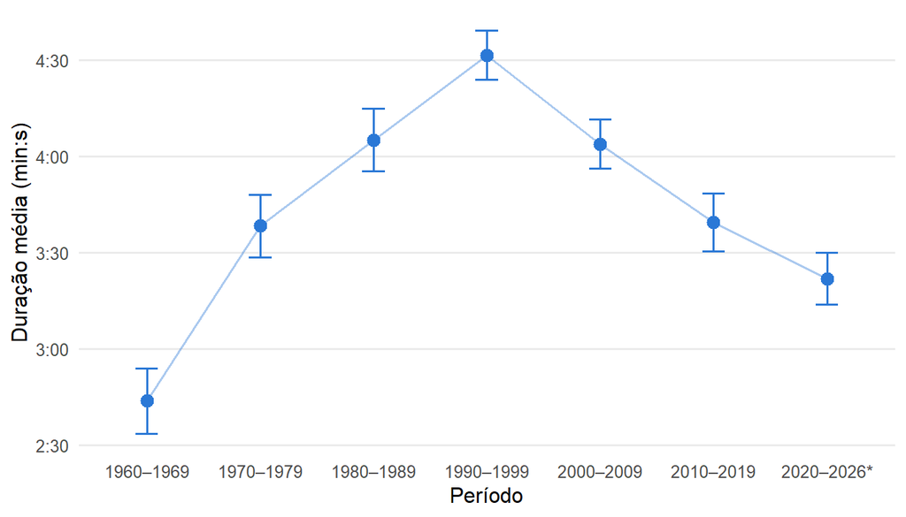

Figura 2.1: Duração média estimada das músicas em 1º lugar, por período, com intervalos de 95% de confiança. *2020–2026 é um período parcial.

A Tabela 2.4 compara os períodos consecutivos. Das 6 diferenças, 6 têm intervalos que não contêm zero, mesmo com a correção para as comparações simultâneas. Assim, tanto o aumento da duração até 1990–1999 quanto a redução posterior são estatisticamente sustentados a cada passo. A diferença entre 2010–2019 e 2020–2026 é a menos precisa: o limite superior do intervalo, -1,4 segundos, fica próximo de zero.

Tabela 2.4: Diferença entre as durações médias de períodos consecutivos, com intervalos simultâneos de 95% (Bonferroni, 6 comparações) e p-valores ajustados por Holm.

| Comparação | Diferença (s) | IC 95% simultâneo (s) | p (Holm) |
| --- | --- | --- | --- |
| 1970–1979 − 1960–1969 | 54,6 | 35,6 a 73,6 | < 0,001 |
| 1980–1989 − 1970–1979 | 26,7 | 8,2 a 45,3 | < 0,001 |
| 1990–1999 − 1980–1989 | 26,4 | 9,7 a 43,1 | < 0,001 |
| 2000–2009 − 1990–1999 | -27,6 | -42,2 a -13,1 | < 0,001 |
| 2010–2019 − 2000–2009 | -24,4 | -40,3 a -8,5 | < 0,001 |
| 2020–2026* − 2010–2019 | -17,6 | -33,8 a -1,4 | 0,004 |

A distribuição das durações é assimétrica à direita em alguns períodos, por causa de poucas músicas longas. O caso mais marcante é “Hey Jude”, com 7:11, em 1960–1969; sem ela, a média do período seria de 2:39. Essas músicas fazem parte da população e foram mantidas. Com 60 observações por estrato, a assimetria observada não compromete o uso da distribuição t. A mediana amostral (Tabela 2.3) é apresentada apenas como medida complementar e segue o mesmo padrão de crescimento e queda da média.

### 2.4.2 Proporção de artistas mulheres

A Tabela 2.5 e a Figura 2.2 apresentam as estimativas finais da proporção de semanas com artista mulher.

Tabela 2.5: Proporção estimada de semanas com artista mulher no 1º lugar (definição principal) e com artista feminino ou grupo misto (medida complementar), com erro-padrão (EP) e intervalos de 95% de confiança. *2020–2026 é um período parcial.

| Período | Semanas | Artista mulher | EP (p.p.) | IC 95% | Feminino ou misto | IC 95% |
| --- | --- | --- | --- | --- | --- | --- |
| 1960–1969 | 10/60 | 16,7% | 4,6 | 7,7% a 25,6% | 18,3% | 9,0% a 27,6% |
| 1970–1979 | 9/60 | 15,0% | 4,4 | 6,4% a 23,6% | 23,3% | 13,2% a 33,5% |
| 1980–1989 | 15/60 | 25,0% | 5,3 | 14,6% a 35,4% | 35,0% | 23,6% a 46,4% |
| 1990–1999 | 27/60 | 45,0% | 6,1 | 33,1% a 56,9% | 46,7% | 34,7% a 58,6% |
| 2000–2009 | 22/60 | 36,7% | 5,9 | 25,1% a 48,2% | 45,0% | 33,1% a 56,9% |
| 2010–2019 | 21/60 | 35,0% | 5,8 | 23,5% a 46,5% | 35,0% | 23,5% a 46,5% |
| 2020–2026* | 24/60 | 40,0% | 5,8 | 28,6% a 51,4% | 40,0% | 28,6% a 51,4% |

A proporção estimada ficou entre 15% e 25% de 1960 a 1989 e entre 35% e 45% de 1990 a 2026. As margens de erro ficaram entre 9 e 12 pontos percentuais.

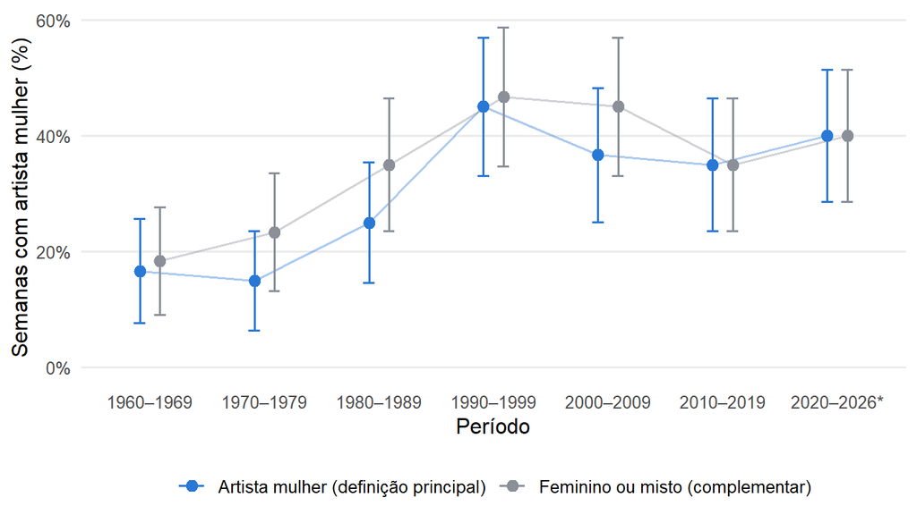

Figura 2.2: Proporção estimada de semanas com artista mulher no 1º lugar, por período, com intervalos de 95% de confiança. Em cinza, a medida complementar: artista feminino ou grupo misto. *2020–2026 é um período parcial.

Na comparação entre períodos consecutivos (Tabela 2.6), nenhuma diferença é estatisticamente sustentada após a correção para comparações múltiplas. A maior delas, de 20,0 pontos percentuais entre 1980–1989 e 1990–1999, tem intervalo simultâneo de -1,3 a 41,3 pontos. Assim, mesmo com 60 semanas por período, não é possível afirmar em que década a mudança ocorreu.

Tabela 2.6: Diferença entre as proporções de semanas com artista mulher em períodos consecutivos, em pontos percentuais, com intervalos simultâneos de 95% (Bonferroni, 6 comparações) e p-valores ajustados por Holm.

| Comparação | Diferença (p.p.) | IC 95% simultâneo (p.p.) | p (Holm) |
| --- | --- | --- | --- |
| 1970–1979 − 1960–1969 | -1,7 | -18,3 a 15,0 | 1,000 |
| 1980–1989 − 1970–1979 | 10,0 | -8,1 a 28,1 | 0,729 |
| 1990–1999 − 1980–1989 | 20,0 | -1,3 a 41,3 | 0,080 |
| 2000–2009 − 1990–1999 | -8,3 | -30,7 a 14,0 | 1,000 |
| 2010–2019 − 2000–2009 | -1,7 | -23,6 a 20,2 | 1,000 |
| 2020–2026* − 2010–2019 | 5,0 | -16,7 a 26,7 | 1,000 |

Agrupando os períodos em dois blocos com o estimador estratificado, a proporção foi de 18,9% em 1960–1989 e de 39,1% em 1990–2026. A diferença, de 20,2 pontos percentuais, tem intervalo de 95% de 12,2 a 28,2 pontos. Ela é estatisticamente sustentada e indica um aumento da liderança feminina entre as duas metades do período estudado.

A medida complementar (feminino ou misto) segue o mesmo padrão, com valores um pouco maiores nos períodos em que os grupos mistos eram mais frequentes. Ela ainda não inclui as participações especiais de mulheres.

### 2.4.3 Análise de sensibilidade da duração

A Tabela 2.7 avalia duas fontes de incerteza da medição que não aparecem nos intervalos de confiança:

- **Radio edit:** a coluna “Radio edit” substitui a versão de álbum pela de rádio nas 15 músicas em que a Wikipedia só distinguia essas duas versões.
- **Coleta original:** as duas últimas colunas comparam, para as mesmas 30 semanas da etapa 1 de cada período, a média com as durações da coleta original e com as da nova coleta.

Tabela 2.7: Sensibilidade da duração média ao critério de versão (álbum ou *radio edit*) e ao método de coleta (original, pela mediana das gravações, ou novo, pela versão single). Durações em min:s. *2020–2026 é um período parcial.

| Período | Média principal | Radio edit | Diferença (s) | Etapa 1: coleta original | Etapa 1: nova coleta | Diferença (s) |
| --- | --- | --- | --- | --- | --- | --- |
| 1960–1969 | 2:44 | 2:44 | 0,0 | 2:47 | 2:43 | -4,7 |
| 1970–1979 | 3:38 | 3:38 | 0,0 | 3:47 | 3:34 | -12,6 |
| 1980–1989 | 4:05 | 4:05 | -0,3 | 4:26 | 4:04 | -21,3 |
| 1990–1999 | 4:31 | 4:25 | -6,8 | 4:25 | 4:32 | 6,7 |
| 2000–2009 | 4:04 | 4:00 | -4,2 | 3:57 | 4:01 | 3,8 |
| 2010–2019 | 3:39 | 3:38 | -1,9 | 3:47 | 3:46 | -0,8 |
| 2020–2026* | 3:22 | 3:21 | -0,9 | 3:22 | 3:23 | 1,1 |

O critério de versão afeta principalmente 1990–1999: com o *radio edit*, a média cai 6,8 segundos, mas o período continua com a maior duração média (4:25, contra 4:05 no segundo maior). Já a coleta original superestimava as durações de 1970–1989, por incluir versões longas de álbum, estendidas e de 12 polegadas. Em 1980–1989, a diferença nas mesmas semanas chega a 21 segundos. Com a correção, o pico de duração deixa de ser dividido entre os anos 1980 e 1990 e passa a ser claramente em 1990–1999.

## 2.5 Etapa 1 × Resultado Final

A Figura 2.3 e a Tabela 2.8 comparam, para os 7 períodos analisados, as estimativas da etapa 1, mostradas na apresentação (30 semanas e coleta original da duração), com as estimativas finais (60 semanas e duração pela versão single).

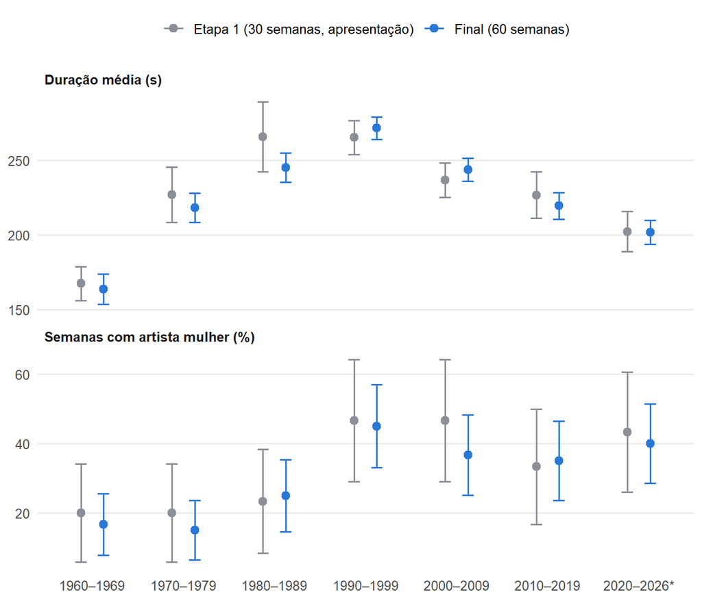

Figura 2.3: Estimativas da etapa 1 (30 semanas por período, coleta original, resultados da apresentação) e finais (60 semanas por período, duração pela versão single), com intervalos de 95% de confiança. *2020–2026 é um período parcial.

Tabela 2.8: Estimativas da etapa 1 (30 semanas, coleta original) e finais (60 semanas, versão single), com a margem de erro de 95%. *2020–2026 é um período parcial.

| Período | Duração: etapa 1 | Duração: final | Mulheres: etapa 1 | Mulheres: final |
| --- | --- | --- | --- | --- |
| 1960–1969 | 2:47 (± 11 s) | 2:44 (± 10 s) | 20% (± 14 p.p.) | 17% (± 9 p.p.) |
| 1970–1979 | 3:47 (± 18 s) | 3:38 (± 10 s) | 20% (± 14 p.p.) | 15% (± 9 p.p.) |
| 1980–1989 | 4:26 (± 23 s) | 4:05 (± 10 s) | 23% (± 15 p.p.) | 25% (± 10 p.p.) |
| 1990–1999 | 4:25 (± 11 s) | 4:31 (± 8 s) | 47% (± 18 p.p.) | 45% (± 12 p.p.) |
| 2000–2009 | 3:57 (± 12 s) | 4:04 (± 8 s) | 47% (± 18 p.p.) | 37% (± 12 p.p.) |
| 2010–2019 | 3:47 (± 16 s) | 3:39 (± 9 s) | 33% (± 17 p.p.) | 35% (± 11 p.p.) |
| 2020–2026* | 3:22 (± 13 s) | 3:22 (± 8 s) | 43% (± 17 p.p.) | 40% (± 11 p.p.) |

**O que se confirmou.** As duas tendências apresentadas na etapa 1 se mantêm com a amostra ampliada: a duração média cresce desde os anos 1960, atinge o máximo por volta dos anos 1990 e depois cai, e a presença feminina é maior de 1990 em diante do que de 1960 a 1989.

**O que mudou.** Com a duração medida pela versão single, as médias de 1970–1989 diminuíram, e o pico, que na etapa 1 aparecia em 1980–1989 (empatado com 1990–1999), passou a ser claramente em 1990–1999. Em 1980–1989, a estimativa passou de 4:26 para 4:05. Com 60 semanas por período, as margens de erro também diminuíram: na duração, de 11–23 segundos para 8–10; na proporção, de 14–18 para 9–12 pontos percentuais.

## 2.6 Considerações Finais

Este estudo estimou, a partir de uma amostra estratificada de 420 semanas, a duração média e a proporção de artistas mulheres entre as músicas que ocuparam o 1º lugar da Billboard Hot 100, em 7 períodos de 1960 a 2026. O trabalho foi feito em duas etapas. O planejamento, com uma amostra piloto e uma simulação, mostrou que a meta de precisão exigiria 656 semanas e que, para comparar períodos, a alocação igual é a mais adequada. A etapa 1, com 30 semanas por período, foi a apresentada em sala; a etapa 2 ampliou a amostra para 60 semanas por período e corrigiu a medição da duração, confirmando as tendências da etapa 1.

**Duração.** A duração média das músicas em 1º lugar cresceu de cerca de 2:44 em 1960–1969 para 4:31 em 1990–1999 e depois diminuiu, chegando a 3:22 em 2020–2026. Das 6 diferenças entre períodos consecutivos, 6 são estatisticamente sustentadas, com intervalos simultâneos que levam em conta as comparações múltiplas. A redução mais recente, de 2010–2019 para 2020–2026, é a menos precisa. Além disso, 2020–2026 é um período parcial, cuja estimativa pode mudar até o fim da década.

**Presença feminina.** A proporção de semanas com uma mulher como artista principal ficou entre 15% e 25% de 1960 a 1989 e entre 35% e 45% a partir de 1990. O aumento entre os blocos 1960–1989 e 1990–2026, de cerca de 20 pontos percentuais, é estatisticamente sustentado. Já as diferenças entre décadas vizinhas não são: com 60 semanas por período, não é possível identificar em que década a mudança ocorreu, nem afirmar que houve queda ou aumento depois de 1990.

**Limitações.**

- A duração depende da identificação da versão single, que nem sempre está bem documentada. A escolha entre versão de álbum e de rádio altera a média de 1990–1999 em cerca de 7 segundos, sem mudar as conclusões.
- A variável de gênero mede liderança feminina: ignora participações especiais, cada vez mais frequentes, e trata grupos mistos à parte.
- A parada foi construída em contextos tecnológicos e comerciais diferentes ao longo do período. Por isso, a comparação histórica é descritiva: o estudo não permite atribuir as mudanças observadas a nenhuma causa específica.
- Esses erros de medição e de definição não são capturados pelos intervalos de confiança, que refletem apenas o erro amostral.

Em um estudo futuro, seria interessante:

- registrar a presença de mulheres entre todos os artistas creditados, incluindo participações;
- ampliar a amostra, para distinguir décadas vizinhas na proporção;
- conferir as durações diretamente nos selos dos compactos e nas edições originais dos singles.

# Referências

Billboard. 2026. “Billboard Hot 100.” https://www.billboard.com/charts/hot-100/.

Bolfarine, Heleno, and Wilton de Oliveira Bussab. 2005. *Elementos de Amostragem*. São Paulo: Edgard Blücher.

Cochran, William G. 1977. *Sampling Techniques*. 3rd ed. New York: John Wiley & Sons.

MetaBrainz Foundation. 2026. “MusicBrainz: The Open Music Encyclopedia.” https://musicbrainz.org.

Wikipedia. 2026. “Wikipedia, the Free Encyclopedia.” https://en.wikipedia.org.